# Association Rule Mining

July 9, 2015

## My Background

- Currently a Data Scientist at Trinity Health
- Previously a Data Analyst for a large physician practice
- MA Economics (Econometrics, Environmental Econ)

Brandon.Stange@gmail.com

## Accuracy vs. Interpretability

**Maximally Accurate**

- Non-Linear
- Feature Engineering/Interaction
- Ensembling

**Maximally Interpretable**

- Rule-Based
- Single Decision Trees
- Linear/Logistic Regression

## Association Rule Uses

- Originally used for *market basket analysis*
  - Find sets of products that are often bought together
  - Improve product arrangement
  - Targeted Advertising
  - {Beer} -> {Pizza}
- Can be used for any dataset that can be represented as a binary matrix
- Traditionally unsupervised, but can target specific outcomes
- Can target more than one outcome at once

## Algorithms and Implimentations

- Apriori
  - R, Python, SQL Server, Oracle, everywhere
- Eclat
  - R, Python, C, others
- FP Growth
  - C, Python, mahout
- Graph Databases
  - neo4j, Titan, Giraph

## Arules Package Ecosystem

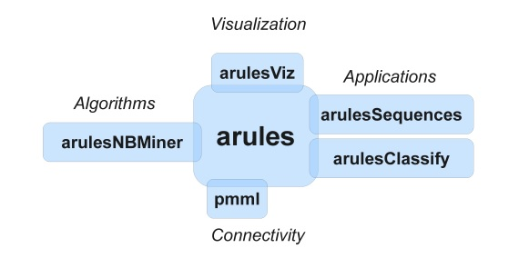

## Input Data Structure

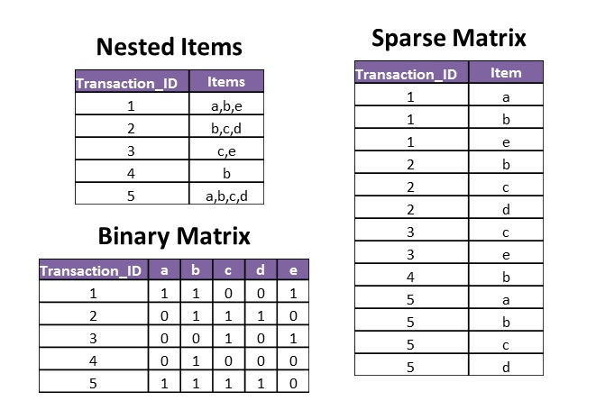

## Rule Interpretation (Apriori Output)

|  | lhs | rhs | support | confidence | lift |
| --- | --- | --- | --- | --- | --- |
| 16 | {b,c} | {d} | 0.4 | 1 | 2.5 |

RHS (Outcome) = **{d}**

LHS (Inputs) = **{b,c}** LHS occurs in **40%** of total population.

RHS occurs in **100%** of these transactions, which is **2.5** times the population at large.

## Apriori Function Call

```r
apriori(data,
         parameter = list(minlen=1,
                          support=0.05,
                          confidence=0.4,
                          maxlen=3),
         appearance = list(rhs=outcomelist,
                           default="lhs"),
         control = list(verbose=T))
```

## Itemset Graph Representation

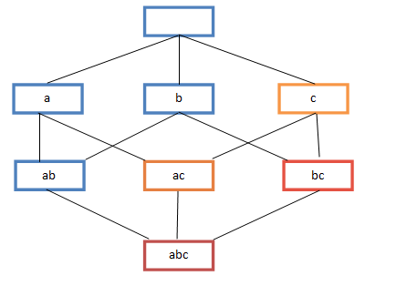

## Real Data Example

**490k records from New York City resturant inspections**

requires readr, dplyr, tidyr, arules, arulesviz (https://data.cityofnewyork.us)

**Fields of interest:**

- ID, name, address, phone, etc.
- Inspection Date
- Borough
- Cuisine Description
- Violation Description
- Action

## Data Pre-Processing

1. Clean up dates and special characters
2. Apply custom violation code grouping
3. Use tidyr::gather to put data in 'long' format
4. Replace keys and measures with integer IDs
5. Convert to sparse matrix

## Pre-Processing steps 3-5 Code

```r
## 3. Use tidyr::gather to put data in 'long' format
nycs <- nycw %>%
  select(INSID, BORO, CUISINE_DESCRIPTION, VIOLATION_TYPE) %>%
  gather(MEASURE, VALUE, -INSID)
nycs$MEASURE <- nycs$VALUE
nycs$VALUE <- 1

## 4. Replace keys and measures with integer IDs
ID <- unique(nycs$INSID)
ME <- unique(nycs$MEASURE)
nycs$MEASURE<-match(nycs$MEASURE,ME)
nycs$INSID<-match(nycs$INSID,ID)

## 5. Convert to sparse matrix
sm<-sparseMatrix(i=nycs$INSID, j=nycs$MEASURE,x=nycs$VALUE,
                 dimnames=list(ID,ME),giveCsparse=T)
```

## Example Function Call

```r
rules <- apriori(sm2,
                   parameter = list(minlen=1, supp=0.001, conf=0.4, maxlen=4),
                   appearance = list(rhs=outcomelist,
                                     default="lhs"),
                   control = list(verbose=T))
```

```r
outcomelist
```

```
## [1] "Food Handling"      "Rodents/Pests"      "Employee Practices"
## [4] "Temperature"        "Adminstrative"      "Poor Equipment"
## [7] "Food Source"
```

```r
class(sm2)
```

```
## [1] "transactions"
## attr(,"package")
## [1] "arules"
```

## Results

|  | lhs | rhs | support | confidence | lift |
| --- | --- | --- | --- | --- | --- |
| 23 | {BROOKLYN,Caribbean} | {Rodents/Pests} | 0.008 | 0.605 | 1.396 |
| 1 | {Delicatessen} | {Temperature} | 0.010 | 0.599 | 1.353 |
| 5 | {Caribbean} | {Rodents/Pests} | 0.016 | 0.570 | 1.315 |
| 35 | {MANHATTAN,Chinese} | {Temperature} | 0.015 | 0.575 | 1.299 |
| 2 | {Pizza/Italian} | {Temperature} | 0.012 | 0.556 | 1.257 |

## arulesViz plots

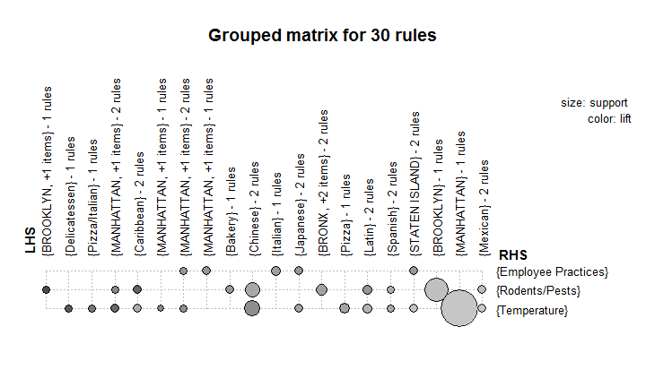

```r
plot(rules,method="grouped")
```

## arulesViz plots contd

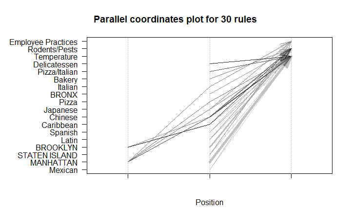

```r
plot(rules,method="paracoord")
```

## arulesViz plots contd

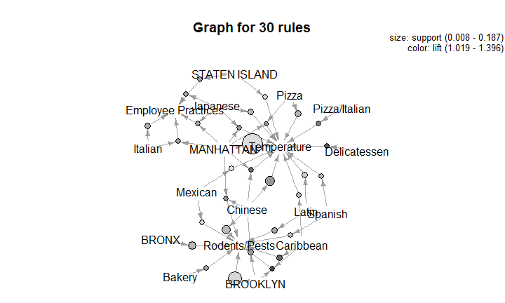

```r
plot(rules,method="graph")
```

## Arules Sequences

- Allows for pattern discovery in ordered sets of discrete data
- Ordered, not temporal (no measure of time between events)
- Right-censored, events *after* the event of interest are ignored
- arulesSequences::cspade()
- Parameters are similar: support, size, gap, window

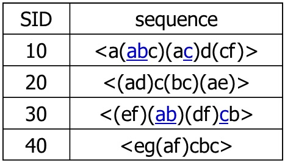

## Resources

**Christian Borgelt's website**

Various publications and implementations of Association Rules

www.borgelt.net

[Efficient Analysis of Pattern and Association Rule Mining Approaches](http://arxiv.org/ftp/arxiv/papers/1402/1402.2892.pdf)